# Context

### Exploratory Data Analysis after data pre-processing

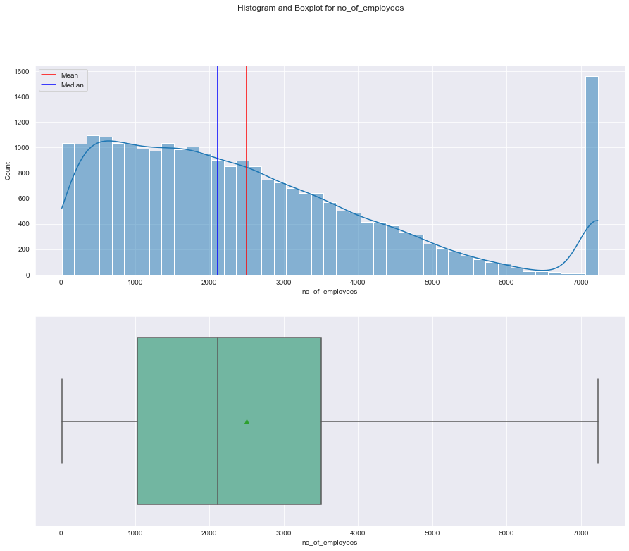

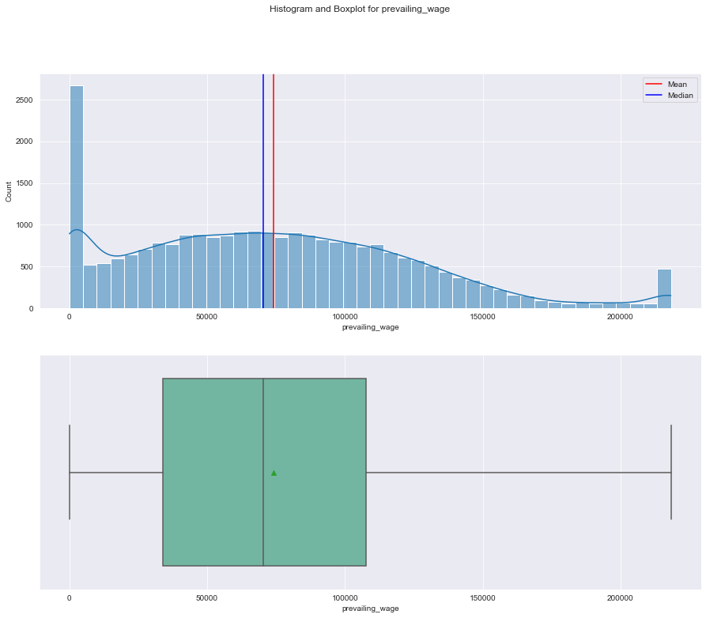

```python
# plotting numerical columns graphs
for i in num_cols:
    Hist_Bar_Plt(data[i],i)
```

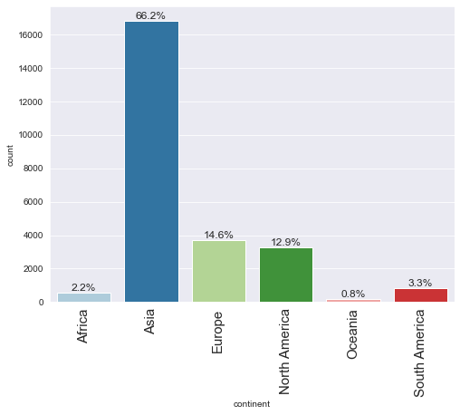

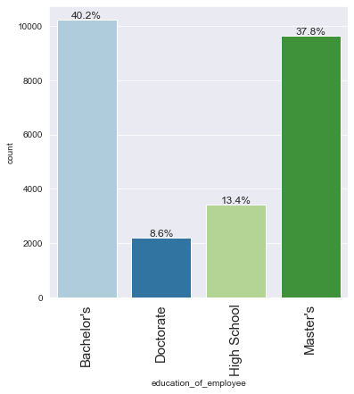

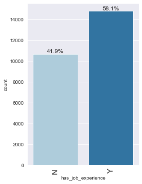

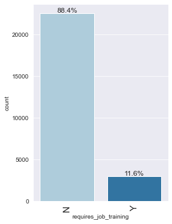

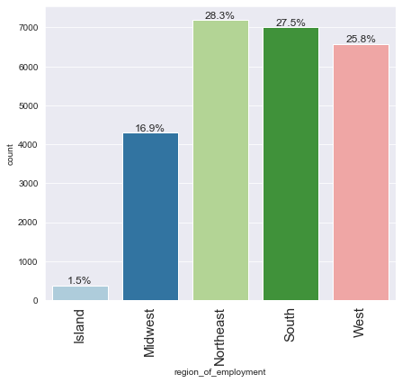

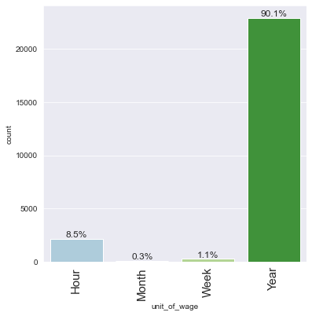

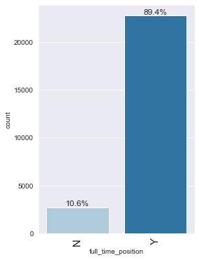

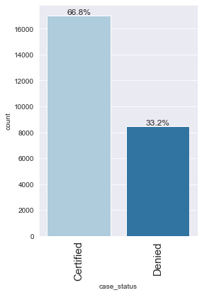

```python
# plotting categorical columns graphs
for i in cat_cols:
    labeled_barplot(data, i, perc=True)
```

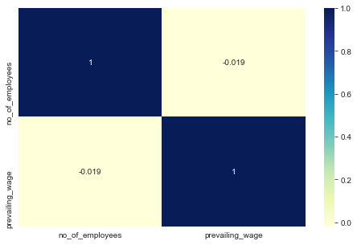

```python
# Heatmap for assessing relation
plt.figure(figsize=(8,5))
sns.heatmap(data.corr(), annot=True, cmap="YlGnBu")
plt.show()
```

```
case_status    Certified  Denied    All
continent
All                17001    8446  25447
Asia               11001    5839  16840
North America       2037    1250   3287
Europe              2953     774   3727
South America        492     359    851
Africa               396     154    550
Oceania              122      70    192
------------------------------------------------------------------------------------------------------------------------
```

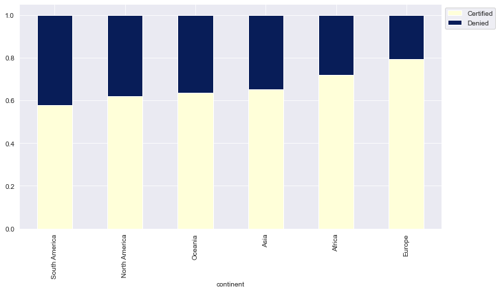

```python
stacked_barplot(data, "continent", "case_status")
```

- South America continent cases have lowest approval rate of 60%
- Europe cases are highest approval rate of 80%

```
case_status            Certified  Denied    All
education_of_employee
All                        17001    8446  25447
Bachelor's                  6362    3858  10220
High School                 1164    2252   3416
Master's                    7565    2057   9622
Doctorate                   1910     279   2189
------------------------------------------------------------------------------------------------------------------------
```

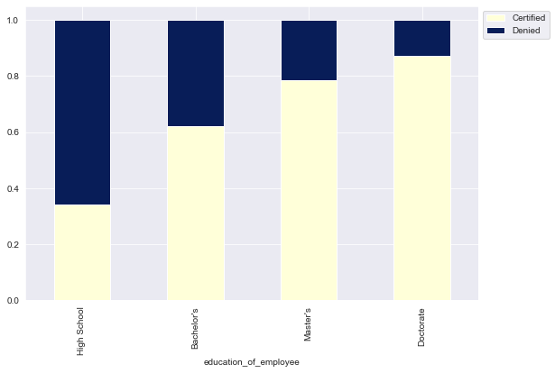

```python
stacked_barplot(data, "education_of_employee", "case_status")
```

- Employees with Doctorate have lowest Denied cases
- 80% of employees with master's have certified cases
- High schoolers have only 30% of certified cases

```
case_status         Certified  Denied    All
has_job_experience
All                     17001    8446  25447
N                        5986    4675  10661
Y                       11015    3771  14786
------------------------------------------------------------------------------------------------------------------------
```

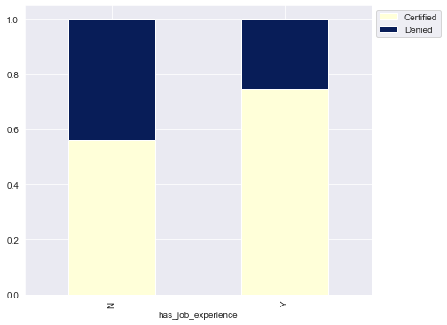

```python
stacked_barplot(data, "has_job_experience", "case_status")
```

```
case_status            Certified  Denied    All
requires_job_training
All                        17001    8446  25447
N                          15000    7498  22498
Y                           2001     948   2949
------------------------------------------------------------------------------------------------------------------------
```

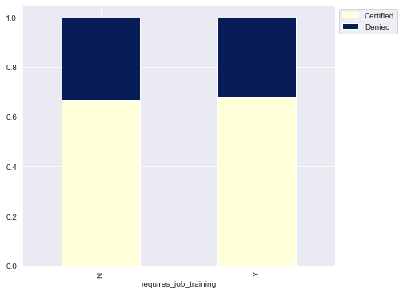

```python
stacked_barplot(data, "requires_job_training", "case_status")
```

- The certified cases distribution is about the same whether a job requires training or not

```
case_status           Certified  Denied    All
region_of_employment
All                       17001    8446  25447
Northeast                  4524    2665   7189
West                       4097    2481   6578
South                      4908    2098   7006
Midwest                    3246    1053   4299
Island                      226     149    375
------------------------------------------------------------------------------------------------------------------------
```

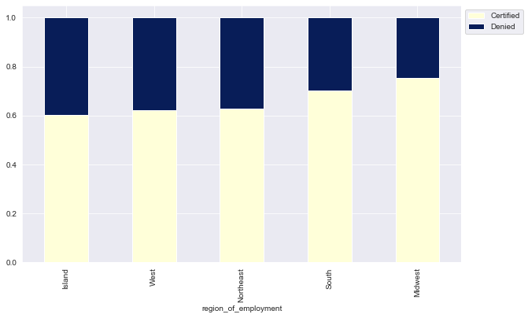

```python
stacked_barplot(data, "region_of_employment", "case_status")
```

- Island, West and Northeast have fairly similar caertified vs denied cases
- Midwest have highest certfied cases

```
case_status   Certified  Denied    All
unit_of_wage
All               17001    8446  25447
Year              16030    6903  22933
Hour                747    1406   2153
Week                169     103    272
Month                55      34     89
------------------------------------------------------------------------------------------------------------------------
```

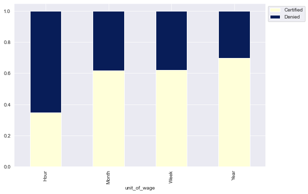

```python
stacked_barplot(data, "unit_of_wage", "case_status")
```

```
case_status         Certified  Denied    All
full_time_position
All                     17001    8446  25447
Y                       15146    7595  22741
N                        1855     851   2706
------------------------------------------------------------------------------------------------------------------------
```

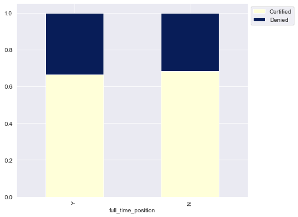

```python
stacked_barplot(data, "full_time_position", "case_status")
```

- No significant difference between full time or not

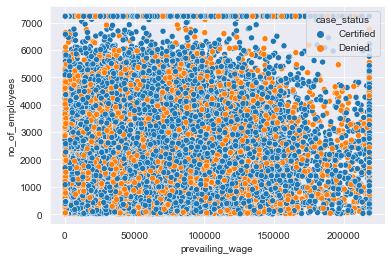

```python
sns.scatterplot(data=data, x='prevailing_wage',y='no_of_employees',hue='case_status')
plt.show()
```

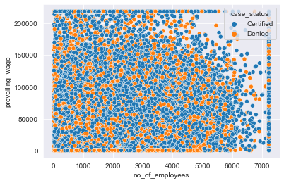

```python
sns.scatterplot(data=data, y='prevailing_wage',x='no_of_employees',hue='case_status')
plt.show()
```

```python
data.sample(5)
```

|  | continent | education_of_employee | has_job_experience | requires_job_training | no_of_employees | region_of_employment | prevailing_wage | unit_of_wage | full_time_position | case_status | nw_yr_of_estab |
| --- | --- | --- | --- | --- | --- | --- | --- | --- | --- | --- | --- |
| 19142 | Asia | Bachelor's | Y | N | 1355.0 | South | 14119.0500 | Year | Y | Certified | less_than_2000 |
| 3594 | Asia | Master's | N | N | 647.0 | Midwest | 59044.8000 | Year | Y | Denied | less_than_2000 |
| 6592 | Europe | Master's | N | N | 5374.0 | Northeast | 61046.1500 | Year | Y | Certified | 2000_and_greater |
| 22452 | South America | Bachelor's | N | N | 2315.0 | Northeast | 387.9725 | Hour | Y | Certified | 2000_and_greater |
| 1362 | North America | Bachelor's | Y | N | 4931.0 | Midwest | 22497.0900 | Year | Y | Certified | less_than_2000 |

- Let's convert text values to numerical

```python
data['has_job_experience'] = data['has_job_experience'].apply(lambda x: 1 if x == 'Y' else 0)
```

```python
data['requires_job_training'] = data['requires_job_training'].apply(lambda x: 1 if x == 'Y' else 0)
```

```python
data['full_time_position'] = data['full_time_position'].apply(lambda x: 1 if x == 'Y' else 0)
```

```python
data['case_status'] = data['case_status'].apply(lambda x: 1 if x == 'Certified' else 0)
```

```python
data.sample(5)
```

|  | continent | education_of_employee | has_job_experience | requires_job_training | no_of_employees | region_of_employment | prevailing_wage | unit_of_wage | full_time_position | case_status | nw_yr_of_estab |
| --- | --- | --- | --- | --- | --- | --- | --- | --- | --- | --- | --- |
| 24538 | North America | High School | 0 | 0 | 5232.00 | Midwest | 218289.9475 | Year | 1 | 1 | less_than_2000 |
| 15323 | North America | Master's | 0 | 1 | 1622.00 | Northeast | 175181.7000 | Year | 1 | 0 | 2000_and_greater |
| 17293 | Europe | Master's | 1 | 0 | 7228.75 | West | 99091.2600 | Year | 1 | 1 | less_than_2000 |
| 9986 | Asia | Bachelor's | 0 | 0 | 3156.00 | South | 211405.6000 | Year | 1 | 0 | less_than_2000 |
| 20894 | Asia | Master's | 0 | 0 | 3207.00 | South | 83203.2400 | Year | 1 | 1 | less_than_2000 |

```python
data.info()
```

```
<class 'pandas.core.frame.DataFrame'>
Int64Index: 25447 entries, 0 to 25479
Data columns (total 11 columns):
 #   Column                 Non-Null Count  Dtype
---  ------                 --------------  -----
 0   continent              25447 non-null  category
 1   education_of_employee  25447 non-null  category
 2   has_job_experience     25447 non-null  category
 3   requires_job_training  25447 non-null  category
 4   no_of_employees        25447 non-null  float64
 5   region_of_employment   25447 non-null  category
 6   prevailing_wage        25447 non-null  float64
 7   unit_of_wage           25447 non-null  category
 8   full_time_position     25447 non-null  category
 9   case_status            25447 non-null  category
 10  nw_yr_of_estab         25447 non-null  object
dtypes: category(8), float64(2), object(1)
memory usage: 2.0+ MB
```

```python
data[["has_job_experience", "requires_job_training","full_time_position","case_status"]] = data[["has_job_experience", "requires_job_training","full_time_position","case_status"]].apply(pd.to_numeric)
```

```python
data.info()
```

```
<class 'pandas.core.frame.DataFrame'>
Int64Index: 25447 entries, 0 to 25479
Data columns (total 11 columns):
 #   Column                 Non-Null Count  Dtype
---  ------                 --------------  -----
 0   continent              25447 non-null  category
 1   education_of_employee  25447 non-null  category
 2   has_job_experience     25447 non-null  int64
 3   requires_job_training  25447 non-null  int64
 4   no_of_employees        25447 non-null  float64
 5   region_of_employment   25447 non-null  category
 6   prevailing_wage        25447 non-null  float64
 7   unit_of_wage           25447 non-null  category
 8   full_time_position     25447 non-null  int64
 9   case_status            25447 non-null  int64
 10  nw_yr_of_estab         25447 non-null  object
dtypes: category(4), float64(2), int64(4), object(1)
memory usage: 2.7+ MB
```

```python
# Let's get the data we need for next steps
X = data.drop(["case_status"], axis=1)
y = data["case_status"]
```

```python
# encode categorical variables
X = pd.get_dummies(X, columns=X.select_dtypes(include=["object", "category"]).columns.tolist(),drop_first=True)
X.head()
```

|  | has_job_experience | requires_job_training | no_of_employees | prevailing_wage | full_time_position | continent_Asia | continent_Europe | continent_North America | continent_Oceania | continent_South America | ... | education_of_employee_High School | education_of_employee_Master's | region_of_employment_Midwest | region_of_employment_Northeast | region_of_employment_South | region_of_employment_West | unit_of_wage_Month | unit_of_wage_Week | unit_of_wage_Year | nw_yr_of_estab_less_than_2000 |
| --- | --- | --- | --- | --- | --- | --- | --- | --- | --- | --- | --- | --- | --- | --- | --- | --- | --- | --- | --- | --- | --- |
| 0 | 0 | 0 | 7228.75 | 592.2029 | 1 | 1 | 0 | 0 | 0 | 0 | ... | 1 | 0 | 0 | 0 | 0 | 1 | 0 | 0 | 0 | 0 |
| 1 | 1 | 0 | 2412.00 | 83425.6500 | 1 | 1 | 0 | 0 | 0 | 0 | ... | 0 | 1 | 0 | 1 | 0 | 0 | 0 | 0 | 1 | 0 |
| 2 | 0 | 1 | 7228.75 | 122996.8600 | 1 | 1 | 0 | 0 | 0 | 0 | ... | 0 | 0 | 0 | 0 | 0 | 1 | 0 | 0 | 1 | 0 |
| 3 | 0 | 0 | 98.00 | 83434.0300 | 1 | 1 | 0 | 0 | 0 | 0 | ... | 0 | 0 | 0 | 0 | 0 | 1 | 0 | 0 | 1 | 1 |
| 4 | 1 | 0 | 1082.00 | 149907.3900 | 1 | 0 | 0 | 0 | 0 | 0 | ... | 0 | 1 | 0 | 0 | 1 | 0 | 0 | 0 | 1 | 0 |

5 rows × 21 columns

```python
# Splitting data into training and test set:
X_train, X_test, y_train, y_test =train_test_split(X, y, test_size=0.3, random_state=1,stratify=y)
print(X_train.shape, X_test.shape)
```

```
(17812, 21) (7635, 21)
```

```python
y.value_counts(1)
```

```
1    0.668094
0    0.331906
Name: case_status, dtype: float64
```

```python
y_train.value_counts(1)
```

```
1    0.668089
0    0.331911
Name: case_status, dtype: float64
```

```python
y_test.value_counts(1)
```

```
1    0.668107
0    0.331893
Name: case_status, dtype: float64
```

## Model Evaluation Criteria

Model can make wrong predictions as:

1. Case is denied when it should be certified
2. Case is certified when it should be denied

## Which case is more important?

- Both cases are important

# How to reduce this loss i.e need to reduce False Negatives?

- We'll focus on accuracy, precision, recall and f1 scores

# Model Building

```python
# Let's define model evaluation functions
# defining a function to compute different metrics to check performance of a classification model built using sklearn
def model_performance_classification_sklearn(model, predictors, target):
    """
    Function to compute different metrics to check classification model performance

    model: classifier
    predictors: independent variables
    target: dependent variable
    """

    # predicting using the independent variables
    pred = model.predict(predictors)

    acc = accuracy_score(target, pred)  # to compute Accuracy
    recall = recall_score(target, pred)  # to compute Recall
    precision = precision_score(target, pred)  # to compute Precision
    f1 = f1_score(target, pred)  # to compute F1-score

    # creating a dataframe of metrics
    df_perf = pd.DataFrame(
        {
            "Accuracy": acc,
            "Recall": recall,
            "Precision": precision,
            "F1": f1,
        },
        index=[0],
    )
    return df_perf
```

```python
def confusion_matrix_sklearn(model, predictors, target):
    """
    To plot the confusion_matrix with percentages

    model: classifier
    predictors: independent variables
    target: dependent variable
    """
    y_pred = model.predict(predictors)
    cm = confusion_matrix(target, y_pred)
    labels = np.asarray(
        [
            ["{0:0.0f}".format(item) + "\n{0:.2%}".format(item / cm.flatten().sum())]
            for item in cm.flatten()
        ]
    ).reshape(2, 2)

    plt.figure(figsize=(6, 4))
    sns.heatmap(cm, annot=labels, fmt="", cmap='YlGnBu')
    plt.ylabel("True label")
    plt.xlabel("Predicted label")
```

```python
## Function to create confusion matrix
def make_confusion_matrix(model,y_actual,labels=[1, 0]):
    '''
    model : classifier to predict values of X
    y_actual : ground truth

    '''
    y_predict = model.predict(X_test)
    cm=metrics.confusion_matrix( y_actual, y_predict, labels=[0, 1])
    df_cm = pd.DataFrame(cm, index = [i for i in ["Actual - No","Actual - Yes"]],
                  columns = [i for i in ['Predicted - No','Predicted - Yes']])
    group_counts = ["{0:0.0f}".format(value) for value in
                cm.flatten()]
    group_percentages = ["{0:.2%}".format(value) for value in
                         cm.flatten()/np.sum(cm)]
    labels = [f"{v1}\n{v2}" for v1, v2 in
              zip(group_counts,group_percentages)]
    labels = np.asarray(labels).reshape(2,2)
    plt.figure(figsize = (10,7))
    sns.heatmap(df_cm, annot=labels,fmt='')
    plt.ylabel('True label')
    plt.xlabel('Predicted label')
```

```python
##  Function to calculate different metric scores of the model - Accuracy, Recall and Precision
def get_metrics_score(model,flag=True):
    '''
    model : classifier to predict values of X

    '''
    # defining an empty list to store train and test results
    score_list=[]

    pred_train = model.predict(X_train)
    pred_test = model.predict(X_test)

    train_acc = model.score(X_train,y_train)
    test_acc = model.score(X_test,y_test)

    train_recall = metrics.recall_score(y_train,pred_train)
    test_recall = metrics.recall_score(y_test,pred_test)

    train_precision = metrics.precision_score(y_train,pred_train)
    test_precision = metrics.precision_score(y_test,pred_test)

    score_list.extend((train_acc,test_acc,train_recall,test_recall,train_precision,test_precision))

    # If the flag is set to True then only the following print statements will be dispayed. The default value is set to True.
    if flag == True:
        print("Accuracy on training set : ",model.score(X_train,y_train))
        print("Accuracy on test set : ",model.score(X_test,y_test))
        print("Recall on training set : ",metrics.recall_score(y_train,pred_train))
        print("Recall on test set : ",metrics.recall_score(y_test,pred_test))
        print("Precision on training set : ",metrics.precision_score(y_train,pred_train))
        print("Precision on test set : ",metrics.precision_score(y_test,pred_test))

    return score_list # returning the list with train and test scores
```

# Decision Tree

- We'll build decision tree using class weights

```python
dtree = DecisionTreeClassifier(criterion='gini',class_weight={0:0.66,1:0.34},random_state=1)
```

```python
dtree.fit(X_train, y_train)
```

```
DecisionTreeClassifier(class_weight={0: 0.66, 1: 0.34}, random_state=1)
```

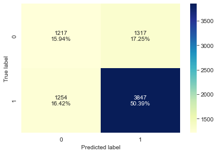

```python
confusion_matrix_sklearn(dtree, X_test, y_test)
```

```python
dtree_model_train_perf=model_performance_classification_sklearn(dtree, X_train, y_train)
print("Training performance \n",dtree_model_train_perf)
```

```
Training performance
    Accuracy  Recall  Precision   F1
0       1.0     1.0        1.0  1.0
```

```python
dtree_model_test_perf=model_performance_classification_sklearn(dtree, X_test, y_test)
print("Testing performance \n",dtree_model_test_perf)
```

```
Testing performance
    Accuracy    Recall  Precision        F1
0  0.663261  0.754166   0.744965  0.749537
```

- The model fits perfectly on the training data indicating an overfit
- The accuracy score is very low on the testing data
- All the scores are lower for the test data

# Bagging Classifier

```python
bagging = BaggingClassifier(random_state=1)
```

```python
bagging.fit(X_train,y_train)
```

```
BaggingClassifier(random_state=1)
```

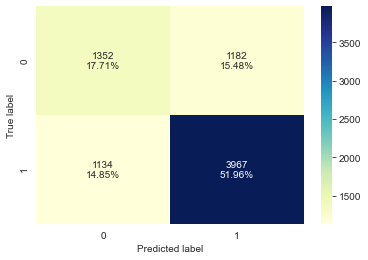

```python
confusion_matrix_sklearn(bagging, X_test, y_test)
```

```python
bagging_model_train_perf=model_performance_classification_sklearn(bagging, X_train, y_train)
print("Training performance \n",bagging_model_train_perf)
```

```
Training performance
    Accuracy    Recall  Precision      F1
0   0.98254  0.984454   0.989359  0.9869
```

```python
bagging_model_test_perf=model_performance_classification_sklearn(bagging, X_test, y_test)
print("Testing performance \n",bagging_model_test_perf)
```

```
Testing performance
    Accuracy    Recall  Precision        F1
0   0.69666  0.777691   0.770441  0.774049
```

- The accuracy for test data is improved
- The recall, precision and f1 have improved
- There is still gap between train and test performance, indicating presence of overfitting

# Random Forest

```python
rf = RandomForestClassifier(random_state=1)
```

```python
rf.fit(X_train,y_train)
```

```
RandomForestClassifier(random_state=1)
```

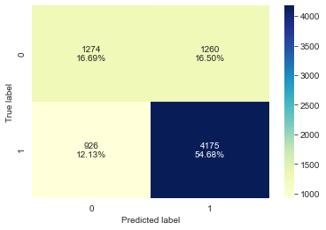

```python
confusion_matrix_sklearn(rf,X_test,y_test)
```

```python
rf_model_train_perf=model_performance_classification_sklearn(rf,X_train,y_train)
print("Training performance \n",rf_model_train_perf)
```

```
Training performance
    Accuracy  Recall  Precision        F1
0  0.999944     1.0   0.999916  0.999958
```

```python
rf_model_test_perf=model_performance_classification_sklearn(rf,X_test,y_test)
print("Testing performance \n",rf_model_test_perf)
```

```
Testing performance
    Accuracy    Recall  Precision        F1
0  0.713687  0.818467   0.768169  0.792521
```

- The performance for training dataset is still high
- The performance of test data has improved
- The accuracy has improved in this model
- The model has also improved recall, precision and f1 score

# Bagging Classifier With Weighted Decision Tree

```python
bagging_wt = BaggingClassifier(base_estimator=DecisionTreeClassifier(criterion='gini',class_weight={0:0.66,1:0.34},random_state=1),random_state=1)
```

```python
bagging_wt.fit(X_train,y_train)
```

```
BaggingClassifier(base_estimator=DecisionTreeClassifier(class_weight={0: 0.66,
                                                                      1: 0.34},
                                                        random_state=1),
                  random_state=1)
```

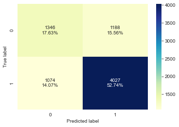

```python
confusion_matrix_sklearn(bagging_wt,X_test,y_test)
```

```python
bagging_wt_model_train_perf=model_performance_classification_sklearn(bagging_wt,X_train,y_train)
print("Training performance \n",bagging_wt_model_train_perf)
```

```
Training performance
    Accuracy    Recall  Precision       F1
0  0.984505  0.986387   0.990381  0.98838
```

```python
bagging_wt_model_test_perf=model_performance_classification_sklearn(bagging_wt, X_test, y_test)
print("Testing performance \n",bagging_wt_model_test_perf)
```

```
Testing performance
    Accuracy    Recall  Precision        F1
0  0.703733  0.789453   0.772196  0.780729
```

- The performance has slightly improved the performance as compared to bagging classifier without decision tree
- The accuracy, recall, precicion and f1 all see positive increase ## Random Forest with Class Weight

```python
rf_wt = RandomForestClassifier(class_weight={0:0.66,1:0.34}, random_state=1)
```

```python
rf_wt.fit(X_train,y_train)
```

```
RandomForestClassifier(class_weight={0: 0.66, 1: 0.34}, random_state=1)
```

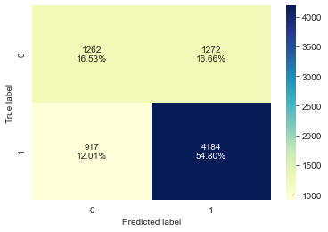

```python
confusion_matrix_sklearn(rf_wt, X_test,y_test)
```

```python
rf_wt_model_train_perf=model_performance_classification_sklearn(rf_wt, X_train,y_train)
print("Training performance \n",rf_wt_model_train_perf)
```

```
Training performance
    Accuracy  Recall  Precision   F1
0       1.0     1.0        1.0  1.0
```

```python
rf_wt_model_test_perf=model_performance_classification_sklearn(rf_wt, X_test,y_test)
print("Testing performance \n",rf_wt_model_test_perf)
```

```
Testing performance
    Accuracy    Recall  Precision        F1
0  0.713294  0.820231   0.766862  0.792649
```

- No significant improvement in random forest after adding weights
- Let's try tuning models

# Tuning Models

```python
# Choose the type of classifier.
dtree_estimator = DecisionTreeClassifier(class_weight={0:0.66,1:0.34},random_state=1)

# Grid of parameters to choose from
parameters = {'max_depth': np.arange(2,30),
              'min_samples_leaf': [1, 2, 5, 7, 10],
              'max_leaf_nodes' : [2, 3, 5, 10,15],
              'min_impurity_decrease': [0.0001,0.001,0.01,0.1]
             }

# Type of scoring used to compare parameter combinations
scorer = metrics.make_scorer(metrics.f1_score)

# Run the grid search
grid_obj = GridSearchCV(dtree_estimator, parameters, scoring=scorer)
grid_obj = grid_obj.fit(X_train, y_train)

# Set the clf to the best combination of parameters
dtree_estimator = grid_obj.best_estimator_

# Fit the best algorithm to the data.
dtree_estimator.fit(X_train, y_train)
```

```
DecisionTreeClassifier(class_weight={0: 0.66, 1: 0.34}, max_depth=2,
                       max_leaf_nodes=2, min_impurity_decrease=0.0001,
                       random_state=1)
```

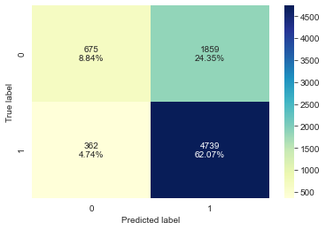

```python
confusion_matrix_sklearn(dtree_estimator, X_test,y_test)
```

```python
dtree_estimator_model_train_perf=model_performance_classification_sklearn(dtree_estimator, X_train,y_train)
print("Training performance \n",dtree_estimator_model_train_perf)
```

```
Training performance
    Accuracy    Recall  Precision        F1
0  0.711599  0.932605   0.719108  0.812059
```

```python
dtree_estimator_model_test_perf=model_performance_classification_sklearn(dtree_estimator, X_test, y_test)
print("Testing performance \n",dtree_estimator_model_test_perf)
```

```
Testing performance
    Accuracy    Recall  Precision        F1
0  0.709103  0.929034   0.718248  0.810155
```

- The gridsearch gives better model
- The overfitting is eliminated
- The recall and f1 score improved significantly

# Tuning Bagging Classifier

```python
# grid search for bagging classifier
cl1 = DecisionTreeClassifier(class_weight={0:0.66,1:0.34},random_state=1)
param_grid = {'base_estimator':[cl1],
              'n_estimators':[5,7,15,51,101],
              'max_features': [0.7,0.8,0.9,1]
             }

grid = GridSearchCV(BaggingClassifier(random_state=1,bootstrap=True), param_grid=param_grid, scoring = 'f1', cv = 5)
grid.fit(X_train, y_train)
```

```
GridSearchCV(cv=5, estimator=BaggingClassifier(random_state=1),
             param_grid={'base_estimator': [DecisionTreeClassifier(class_weight={0: 0.66,
                                                                                 1: 0.34},
                                                                   random_state=1)],
                         'max_features': [0.7, 0.8, 0.9, 1],
                         'n_estimators': [5, 7, 15, 51, 101]},
             scoring='f1')
```

```python
## getting the best estimator
bagging_estimator  = grid.best_estimator_
bagging_estimator.fit(X_train,y_train)
```

```
BaggingClassifier(base_estimator=DecisionTreeClassifier(class_weight={0: 0.66,
                                                                      1: 0.34},
                                                        random_state=1),
                  max_features=0.7, n_estimators=101, random_state=1)
```

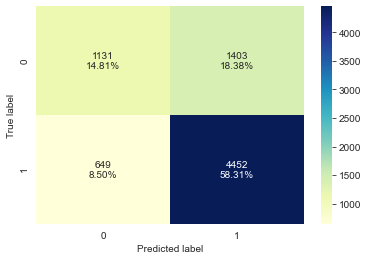

```python
confusion_matrix_sklearn(bagging_estimator, X_test,y_test)
```

```python
bagging_estimator_model_train_perf=model_performance_classification_sklearn(bagging_estimator, X_train,y_train)
print("Training performance \n",bagging_estimator_model_train_perf)
```

```
Training performance
    Accuracy    Recall  Precision        F1
0  0.999663  0.999832   0.999664  0.999748
```

```python
bagging_estimator_model_test_perf=model_performance_classification_sklearn(bagging_estimator, X_test, y_test)
print("Testing performance \n",bagging_estimator_model_test_perf)
```

```
Testing performance
    Accuracy   Recall  Precision        F1
0  0.731238  0.87277   0.760376  0.812705
```

- The accuracy of the model has improved along with other other scores
- The training model has scores close to .99 indicating overfitting

# Tuning Random Forest

```python
# Choose the type of classifier.
rf_estimator = RandomForestClassifier(random_state=1)

rand_obj = RandomizedSearchCV(rf_estimator, parameters, scoring='f1',cv=5)
rand_obj = rand_obj.fit(X_train, y_train)

# Set the clf to the best combination of parameters
rf_estimator = rand_obj.best_estimator_

# Fit the best algorithm to the data.
rf_estimator.fit(X_train, y_train)
```

```
RandomForestClassifier(max_depth=9, max_leaf_nodes=5,
                       min_impurity_decrease=0.001, random_state=1)
```

```python
# Grid of parameters to choose from
parameters = {
        "n_estimators": [251,501],
        "min_samples_leaf": [4,5],
        "max_features": [0.9,'sqrt','auto'],
        "max_samples": [0.9,None],
}

# Run the grid search
grid_obj = GridSearchCV(rf_estimator, parameters, scoring='f1',cv=5)
grid_obj = grid_obj.fit(X_train, y_train)

# Set the clf to the best combination of parameters
rf_estimator = grid_obj.best_estimator_

# Fit the best algorithm to the data.
rf_estimator.fit(X_train, y_train)
```

```
RandomForestClassifier(max_depth=9, max_features=0.9, max_leaf_nodes=5,
                       max_samples=0.9, min_impurity_decrease=0.001,
                       min_samples_leaf=4, n_estimators=251, random_state=1)
```

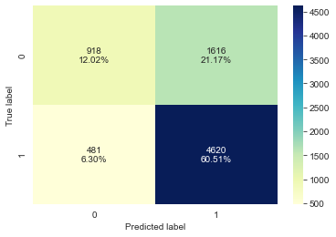

```python
confusion_matrix_sklearn(rf_estimator, X_test,y_test)
```

```python
rf_estimator_model_train_perf=model_performance_classification_sklearn(rf_estimator, X_train,y_train)
print("Training performance \n",rf_estimator_model_train_perf)
```

```
Training performance
    Accuracy    Recall  Precision        F1
0  0.728666  0.911849   0.741442  0.817863
```

```python
rf_estimator_model_test_perf=model_performance_classification_sklearn(rf_estimator, X_test, y_test)
print("Testing performance \n",rf_estimator_model_test_perf)
```

```
Testing performance
    Accuracy    Recall  Precision       F1
0  0.725344  0.905705    0.74086  0.81503
```

- The accuracy has improved with tuned Random Forest Classifier

### Let's check boosting model

# AdaBoost Classifier

```python
abc = AdaBoostClassifier(random_state=1)
abc.fit(X_train,y_train)
```

```
AdaBoostClassifier(random_state=1)
```

```python
AdaBoostClassifier(random_state=1)
```

```
AdaBoostClassifier(random_state=1)
```

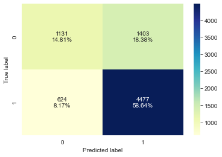

```python
confusion_matrix_sklearn(abc, X_test,y_test)
```

```python
abc_model_train_perf=model_performance_classification_sklearn(abc, X_train,y_train)
print("Training performance \n",abc_model_train_perf)
```

```
Training performance
    Accuracy    Recall  Precision        F1
0  0.737649  0.887899   0.759871  0.818911
```

```python
abc_model_test_perf=model_performance_classification_sklearn(abc, X_test, y_test)
print("Testing performance \n",abc_model_test_perf)
```

```
Testing performance
    Accuracy    Recall  Precision        F1
0  0.734512  0.877671   0.761395  0.815408
```

- The training and test performance is close, removing the possibility of over and under fitting ## Gradient Boosting Classifier

```python
gbc = GradientBoostingClassifier(random_state=1)
gbc.fit(X_train,y_train)
```

```
GradientBoostingClassifier(random_state=1)
```

```python
GradientBoostingClassifier(random_state=1)
```

```
GradientBoostingClassifier(random_state=1)
```

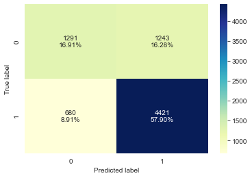

```python
confusion_matrix_sklearn(gbc, X_test,y_test)
```

```python
gbc_model_train_perf=model_performance_classification_sklearn(gbc, X_train,y_train)
print("Training performance \n",gbc_model_train_perf)
```

```
Training performance
    Accuracy    Recall  Precision        F1
0  0.756512  0.877227   0.784003  0.827999
```

```python
gbc_model_test_perf=model_performance_classification_sklearn(gbc, X_test, y_test)
print("Testing performance \n",gbc_model_test_perf)
```

```
Testing performance
    Accuracy    Recall  Precision        F1
0  0.748134  0.866693   0.780544  0.821366
```

```python
xgb = XGBClassifier(random_state=1,eval_metric='logloss')
xgb.fit(X_train,y_train)
```

```
XGBClassifier(base_score=0.5, booster='gbtree', colsample_bylevel=1,
              colsample_bynode=1, colsample_bytree=1, enable_categorical=False,
              eval_metric='logloss', gamma=0, gpu_id=-1, importance_type=None,
              interaction_constraints='', learning_rate=0.300000012,
              max_delta_step=0, max_depth=6, min_child_weight=1, missing=nan,
              monotone_constraints='()', n_estimators=100, n_jobs=4,
              num_parallel_tree=1, predictor='auto', random_state=1,
              reg_alpha=0, reg_lambda=1, scale_pos_weight=1, subsample=1,
              tree_method='exact', validate_parameters=1, verbosity=None)
```

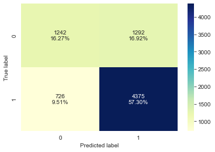

```python
confusion_matrix_sklearn(xgb, X_test,y_test)
```

```python
xgb_model_train_perf=model_performance_classification_sklearn(xgb, X_train,y_train)
print("Training performance \n",xgb_model_train_perf)
```

```
Training performance
    Accuracy   Recall  Precision        F1
0  0.823041  0.92437   0.830063  0.874682
```

```python
xgb_model_test_perf=model_performance_classification_sklearn(xgb, X_test, y_test)
print("Testing performance \n",xgb_model_test_perf)
```

```
Testing performance
    Accuracy    Recall  Precision        F1
0  0.735691  0.857675   0.772013  0.812593
```

- XGBoost gives good accuracy on training data
- The performance drops for testing data

# Tuning AdaBoost Classifier

```python
# Choose the type of classifier.
abc_tuned = AdaBoostClassifier(random_state=1)

# Grid of parameters to choose from
## add from article
parameters = {
    #Let's try different max_depth for base_estimator
    "base_estimator":[DecisionTreeClassifier(max_depth=1, random_state=1),DecisionTreeClassifier(max_depth=2, random_state=1),DecisionTreeClassifier(max_depth=3, random_state=1)],
    "n_estimators": np.arange(10,110,10),
    "learning_rate":np.arange(0.1,2,0.1)
}
abc_tuned = RandomizedSearchCV(abc_tuned, parameters, scoring='f1',cv=5)
abc_tuned = abc_tuned.fit(X_train, y_train)

# Set the clf to the best combination of parameters
abc_tuned_estimator = abc_tuned.best_estimator_

# Fit the best algorithm to the data.
abc_tuned_estimator.fit(X_train, y_train)
```

```
AdaBoostClassifier(base_estimator=DecisionTreeClassifier(max_depth=1,
                                                         random_state=1),
                   learning_rate=0.4, n_estimators=100, random_state=1)
```

```python
# Choose the type of classifier.
abc_tuned = AdaBoostClassifier(random_state=1)

# Grid of parameters to choose from
## add from article
parameters = {
    #Let's try different max_depth for base_estimator
    "base_estimator":[DecisionTreeClassifier(max_depth=2, random_state=1)],
    "n_estimators": np.arange(90,120,10),
    "learning_rate":np.arange(0.1,0.5,0.1)
}

# Run the grid search
grid_obj = GridSearchCV(abc_tuned, parameters, scoring='f1',cv=5)
grid_obj = grid_obj.fit(X_train, y_train)

# Set the clf to the best combination of parameters
abc_tuned = grid_obj.best_estimator_

# Fit the best algorithm to the data.
abc_tuned.fit(X_train, y_train)
```

```
AdaBoostClassifier(base_estimator=DecisionTreeClassifier(max_depth=2,
                                                         random_state=1),
                   learning_rate=0.1, n_estimators=110, random_state=1)
```

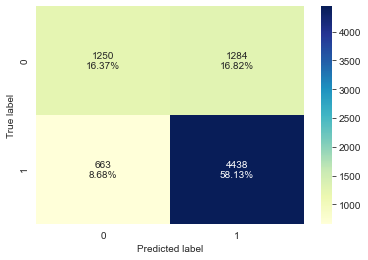

```python
confusion_matrix_sklearn(abc_tuned, X_test,y_test)
```

```python
abc_tuned_model_train_perf=model_performance_classification_sklearn(abc_tuned, X_train,y_train)
print("Training performance \n",abc_tuned_model_train_perf)
```

```
Training performance
    Accuracy    Recall  Precision        F1
0  0.748653  0.879832    0.77458  0.823858
```

```python
abc_tuned_model_test_perf=model_performance_classification_sklearn(abc_tuned, X_test, y_test)
print("Testing performance \n",abc_tuned_model_test_perf)
```

```
Testing performance
    Accuracy    Recall  Precision        F1
0   0.74499  0.870025   0.775603  0.820105
```

- The scores of test and train are close ## Tuned Gradient Boosting

```python
gbc_init = GradientBoostingClassifier(init=AdaBoostClassifier(random_state=1),random_state=1)
gbc_init.fit(X_train,y_train)
```

```
GradientBoostingClassifier(init=AdaBoostClassifier(random_state=1),
                           random_state=1)
```

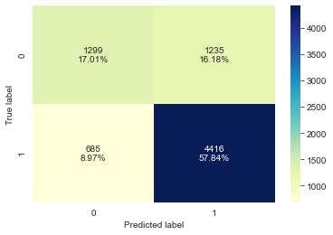

```python
confusion_matrix_sklearn(gbc_init, X_test,y_test)
```

```python
gbc_init_model_train_perf=model_performance_classification_sklearn(gbc_init, X_train,y_train)
print("Training performance \n",gbc_init_model_train_perf)
```

```
Training performance
    Accuracy    Recall  Precision        F1
0  0.756456  0.876303   0.784414  0.827816
```

```python
gbc_init_model_test_perf=model_performance_classification_sklearn(gbc_init, X_test, y_test)
print("Testing performance \n",gbc_init_model_test_perf)
```

```
Testing performance
    Accuracy    Recall  Precision        F1
0  0.748527  0.865713   0.781455  0.821429
```

```python
# Choose the type of classifier.
gbc_tuned = GradientBoostingClassifier(init=AdaBoostClassifier(random_state=1),random_state=1)

# Grid of parameters to choose from
## add from article
parameters = {
    "n_estimators": [100,150,200,250],
    "subsample":[0.8,0.9,1],
    "max_features":[0.7,0.8,0.9,1]
}

# Run the grid search
grid_obj = GridSearchCV(gbc_tuned, parameters, scoring='f1',cv=5)
grid_obj = grid_obj.fit(X_train, y_train)

# Set the clf to the best combination of parameters
gbc_tuned = grid_obj.best_estimator_

# Fit the best algorithm to the data.
gbc_tuned.fit(X_train, y_train)
```

```
GradientBoostingClassifier(init=AdaBoostClassifier(random_state=1),
                           max_features=0.9, random_state=1, subsample=0.9)
```

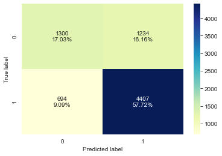

```python
confusion_matrix_sklearn(gbc_tuned, X_test,y_test)
```

```python
gbc_tuned_model_train_perf=model_performance_classification_sklearn(gbc_tuned, X_train,y_train)
print("Training performance \n",gbc_tuned_model_train_perf)
```

```
Training performance
    Accuracy    Recall  Precision        F1
0  0.755333  0.874874   0.783961  0.826926
```

```python
gbc_tuned_model_test_perf=model_performance_classification_sklearn(gbc_tuned, X_test, y_test)
print("Testing performance \n",gbc_tuned_model_test_perf)
```

```
Testing performance
    Accuracy    Recall  Precision        F1
0  0.747479  0.863948   0.781244  0.820518
```

- No siginificant improvement in the grid search result

# Tuned XGBoost Classifier

```python
# Choose the type of classifier.
xgb_tuned = XGBClassifier(random_state=1,eval_metric='logloss')

parameters = {
    "n_estimators": np.arange(10,100,20),
    "scale_pos_weight":[0,1,2,5],
    "subsample":[0.5,0.7,0.9,1],
    "learning_rate":[0.01,0.1,0.2,0.05],
    "gamma":[0,1,3],
    "colsample_bytree":[0.5,0.7,0.9,1],
    "colsample_bylevel":[0.5,0.7,0.9,1]
}

xgb_tuned = RandomizedSearchCV(xgb_tuned, parameters, scoring='f1',cv=5)
xgb_tuned = xgb_tuned.fit(X_train, y_train)

# Set the clf to the best combination of parameters
xgb_tuned_estimator = xgb_tuned.best_estimator_

# Fit the best algorithm to the data.
xgb_tuned_estimator.fit(X_train, y_train)
```

```
XGBClassifier(base_score=0.5, booster='gbtree', colsample_bylevel=0.7,
              colsample_bynode=1, colsample_bytree=0.7,
              enable_categorical=False, eval_metric='logloss', gamma=3,
              gpu_id=-1, importance_type=None, interaction_constraints='',
              learning_rate=0.05, max_delta_step=0, max_depth=6,
              min_child_weight=1, missing=nan, monotone_constraints='()',
              n_estimators=50, n_jobs=4, num_parallel_tree=1, predictor='auto',
              random_state=1, reg_alpha=0, reg_lambda=1, scale_pos_weight=1,
              subsample=0.7, tree_method='exact', validate_parameters=1,
              verbosity=None)
```

```python
# Choose the type of classifier.
xgb_tuned = XGBClassifier(random_state=1,eval_metric='logloss')

# Grid of parameters to choose from
## add from
parameters = {
    "n_estimators": [20,30],
    "scale_pos_weight":[0,1],
    "subsample":[1],
    "learning_rate":[0.1,0.2],
    "gamma":[0,1],
#     "colsample_bytree":[0.5,0.7,0.9,1],
#     "colsample_bylevel":[0.5,0.7,0.9,1]
}

# Run the grid search
grid_obj = GridSearchCV(xgb_tuned, parameters,scoring='f1',cv=5)
grid_obj = grid_obj.fit(X_train, y_train)

# Set the clf to the best combination of parameters
xgb_tuned = grid_obj.best_estimator_

# Fit the best algorithm to the data.
xgb_tuned.fit(X_train, y_train)
```

```
XGBClassifier(base_score=0.5, booster='gbtree', colsample_bylevel=1,
              colsample_bynode=1, colsample_bytree=1, enable_categorical=False,
              eval_metric='logloss', gamma=0, gpu_id=-1, importance_type=None,
              interaction_constraints='', learning_rate=0.1, max_delta_step=0,
              max_depth=6, min_child_weight=1, missing=nan,
              monotone_constraints='()', n_estimators=20, n_jobs=4,
              num_parallel_tree=1, predictor='auto', random_state=1,
              reg_alpha=0, reg_lambda=1, scale_pos_weight=1, subsample=1,
              tree_method='exact', validate_parameters=1, verbosity=None)
```

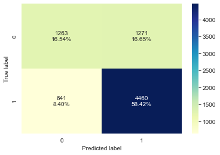

```python
confusion_matrix_sklearn(xgb_tuned, X_test,y_test)
```

```python
xgb_tuned_model_train_perf=model_performance_classification_sklearn(xgb_tuned, X_train,y_train)
print("Training performance \n",xgb_tuned_model_train_perf)
```

```
Training performance
    Accuracy    Recall  Precision        F1
0   0.76033  0.884706   0.784209  0.831431
```

```python
xgb_tuned_model_test_perf=model_performance_classification_sklearn(xgb_tuned, X_test, y_test)
print("Testing performance \n",xgb_tuned_model_test_perf)
```

```
Testing performance
    Accuracy    Recall  Precision        F1
0  0.749574  0.874338   0.778224  0.823486
```

# Comparing the models

```python
models_train_comp_df = pd.concat(
    [dtree_model_train_perf.T,
     bagging_model_train_perf.T,
     rf_model_train_perf.T,
     bagging_wt_model_train_perf.T,
     rf_wt_model_train_perf.T,
     dtree_estimator_model_train_perf.T, bagging_estimator_model_train_perf.T,
     rf_estimator_model_train_perf.T,
     abc_model_train_perf.T,
     gbc_model_train_perf.T,
     xgb_model_train_perf.T,
     abc_tuned_model_train_perf.T,
     gbc_init_model_train_perf.T,
     gbc_tuned_model_train_perf.T,
     xgb_tuned_model_train_perf.T
     ],
    axis=1,
)
models_train_comp_df.columns = [
    "Decision Tree",
    "Bagging Classifier",
    "Random Forest Classifier",
    "Weighted Bagging Classifier",
    "Weighted Random Forest Classifier",
    "Decision Tree Estimator",
    "Bagging Estimator",
    "Random Forest Estimator",
    "AdaBoost Classifier",
    "Gradient Boosting Classifier",
    "XGBoost Classifier",
    "AdaBoost Estimator",
    "Gradient Boost Classifier - Init AdaBoost",
    "Gradient Boost Estimator",
    "XGBoost Estimator"
    ]
print("Training performance comparison:")
models_train_comp_df.T
```

```
Training performance comparison:
```

|  | Accuracy | Recall | Precision | F1 |
| --- | --- | --- | --- | --- |
| Decision Tree | 1.000000 | 1.000000 | 1.000000 | 1.000000 |
| Bagging Classifier | 0.982540 | 0.984454 | 0.989359 | 0.986900 |
| Random Forest Classifier | 0.999944 | 1.000000 | 0.999916 | 0.999958 |
| Weighted Bagging Classifier | 0.984505 | 0.986387 | 0.990381 | 0.988380 |
| Weighted Random Forest Classifier | 1.000000 | 1.000000 | 1.000000 | 1.000000 |
| Decision Tree Estimator | 0.711599 | 0.932605 | 0.719108 | 0.812059 |
| Bagging Estimator | 0.999663 | 0.999832 | 0.999664 | 0.999748 |
| Random Forest Estimator | 0.728666 | 0.911849 | 0.741442 | 0.817863 |
| AdaBoost Classifier | 0.737649 | 0.887899 | 0.759871 | 0.818911 |
| Gradient Boosting Classifier | 0.756512 | 0.877227 | 0.784003 | 0.827999 |
| XGBoost Classifier | 0.823041 | 0.924370 | 0.830063 | 0.874682 |
| AdaBoost Estimator | 0.748653 | 0.879832 | 0.774580 | 0.823858 |
| Gradient Boost Classifier - Init AdaBoost | 0.756456 | 0.876303 | 0.784414 | 0.827816 |
| Gradient Boost Estimator | 0.755333 | 0.874874 | 0.783961 | 0.826926 |
| XGBoost Estimator | 0.760330 | 0.884706 | 0.784209 | 0.831431 |

```python
models_test_comp_df = pd.concat(
    [dtree_model_test_perf.T,
     bagging_model_test_perf.T,
     rf_model_test_perf.T,
     bagging_wt_model_test_perf.T,
     rf_wt_model_test_perf.T,
     dtree_estimator_model_test_perf.T,
     bagging_estimator_model_test_perf.T,
     rf_estimator_model_test_perf.T,
     abc_model_test_perf.T,
     gbc_model_test_perf.T,
     xgb_model_test_perf.T,
     abc_tuned_model_test_perf.T,
     gbc_init_model_test_perf.T,
     gbc_tuned_model_test_perf.T,
     xgb_tuned_model_test_perf.T
     ],
    axis=1,
)
models_test_comp_df.columns = [
    "Decision Tree",
    "Bagging Classifier",
    "Random Forest Classifier",
    "Weighted Bagging Classifier",
    "Weighted Random Forest Classifier",
    "Decision Tree Estimator",
    "Bagging Estimator",
    "Random Forest Estimator",
    "AdaBoost Classifier",
    "Gradient Boosting Classifier",
    "XGBoost Classifier",
    "AdaBoost Estimator",
    "Gradient Boost Classifier - Init AdaBoost",
    "Gradient Boost Estimator",
    "XGBoost Estimator"
    ]
print("Testing performance comparison:")
models_test_comp_df.T
```

```
Testing performance comparison:
```

|  | Accuracy | Recall | Precision | F1 |
| --- | --- | --- | --- | --- |
| Decision Tree | 0.663261 | 0.754166 | 0.744965 | 0.749537 |
| Bagging Classifier | 0.696660 | 0.777691 | 0.770441 | 0.774049 |
| Random Forest Classifier | 0.713687 | 0.818467 | 0.768169 | 0.792521 |
| Weighted Bagging Classifier | 0.703733 | 0.789453 | 0.772196 | 0.780729 |
| Weighted Random Forest Classifier | 0.713294 | 0.820231 | 0.766862 | 0.792649 |
| Decision Tree Estimator | 0.709103 | 0.929034 | 0.718248 | 0.810155 |
| Bagging Estimator | 0.731238 | 0.872770 | 0.760376 | 0.812705 |
| Random Forest Estimator | 0.725344 | 0.905705 | 0.740860 | 0.815030 |
| AdaBoost Classifier | 0.734512 | 0.877671 | 0.761395 | 0.815408 |
| Gradient Boosting Classifier | 0.748134 | 0.866693 | 0.780544 | 0.821366 |
| XGBoost Classifier | 0.735691 | 0.857675 | 0.772013 | 0.812593 |
| AdaBoost Estimator | 0.744990 | 0.870025 | 0.775603 | 0.820105 |
| Gradient Boost Classifier - Init AdaBoost | 0.748527 | 0.865713 | 0.781455 | 0.821429 |
| Gradient Boost Estimator | 0.747479 | 0.863948 | 0.781244 | 0.820518 |
| XGBoost Estimator | 0.749574 | 0.874338 | 0.778224 | 0.823486 |

- The Decision Tree Estimator has highest recall score
- The Boosting Estimators have fairly same scores
- Overall, the XGBoost Estimator has the best performance

```python
print(pd.DataFrame(rf_estimator.feature_importances_, columns = ["Imp"], index = X_train.columns).sort_values(by = 'Imp', ascending = False))
```

```
                                        Imp
education_of_employee_High School  0.488716
has_job_experience                 0.221719
prevailing_wage                    0.164424
continent_Europe                   0.056367
unit_of_wage_Year                  0.048452
education_of_employee_Master's     0.018651
region_of_employment_Midwest       0.001266
education_of_employee_Doctorate    0.000405
continent_Oceania                  0.000000
continent_South America            0.000000
requires_job_training              0.000000
continent_North America            0.000000
continent_Asia                     0.000000
full_time_position                 0.000000
region_of_employment_Northeast     0.000000
region_of_employment_South         0.000000
region_of_employment_West          0.000000
unit_of_wage_Month                 0.000000
unit_of_wage_Week                  0.000000
no_of_employees                    0.000000
nw_yr_of_estab_less_than_2000      0.000000
```

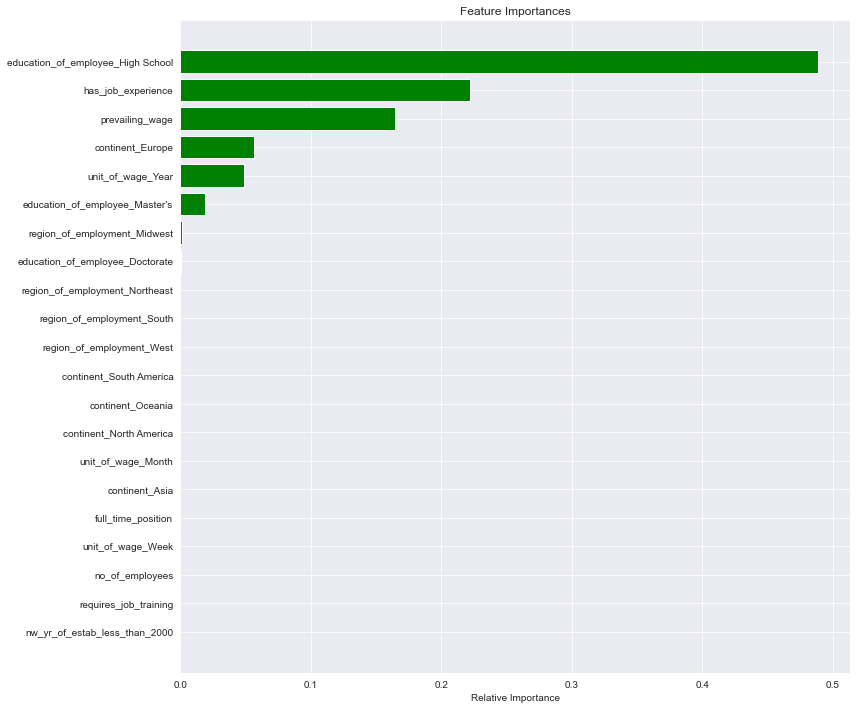

```python
feature_names = X_train.columns
importances = rf_estimator.feature_importances_
indices = np.argsort(importances)

plt.figure(figsize=(12,12))
plt.title('Feature Importances')
plt.barh(range(len(indices)), importances[indices], color='green', align='center')
plt.yticks(range(len(indices)), [feature_names[i] for i in indices])
plt.xlabel('Relative Importance')
plt.show()
```

```python
print(pd.DataFrame(gbc_tuned.feature_importances_, columns = ["Imp"], index = X_train.columns).sort_values(by = 'Imp', ascending = False))
```

```
                                        Imp
education_of_employee_High School  0.278719
has_job_experience                 0.163797
prevailing_wage                    0.113214
education_of_employee_Master's     0.085380
education_of_employee_Doctorate    0.072269
continent_Europe                   0.067722
unit_of_wage_Year                  0.064852
region_of_employment_Midwest       0.037480
continent_North America            0.020325
no_of_employees                    0.019627
region_of_employment_West          0.018387
region_of_employment_South         0.017461
region_of_employment_Northeast     0.009261
continent_South America            0.008910
full_time_position                 0.007980
continent_Asia                     0.007130
requires_job_training              0.004895
nw_yr_of_estab_less_than_2000      0.001538
continent_Oceania                  0.000583
unit_of_wage_Week                  0.000276
unit_of_wage_Month                 0.000194
```

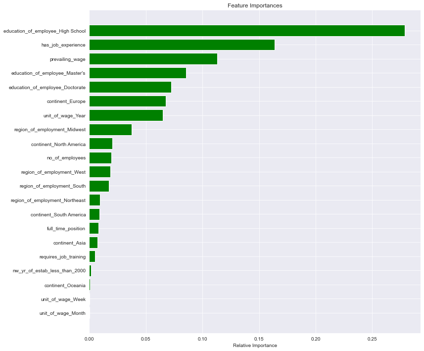

```python
feature_names = X_train.columns
importances = gbc_tuned.feature_importances_
indices = np.argsort(importances)

plt.figure(figsize=(12,12))
plt.title('Feature Importances')
plt.barh(range(len(indices)), importances[indices], color='green', align='center')
plt.yticks(range(len(indices)), [feature_names[i] for i in indices])
plt.xlabel('Relative Importance')
plt.show()
```

```python
print(pd.DataFrame(xgb_tuned.feature_importances_, columns = ["Imp"], index = X_train.columns).sort_values(by = 'Imp', ascending = False))
```

```
                                        Imp
education_of_employee_High School  0.466743
has_job_experience                 0.131286
education_of_employee_Master's     0.073515
education_of_employee_Doctorate    0.059117
continent_Europe                   0.049986
unit_of_wage_Year                  0.043479
region_of_employment_Midwest       0.035305
region_of_employment_South         0.026251
full_time_position                 0.015581
continent_Asia                     0.015325
continent_North America            0.014540
prevailing_wage                    0.012873
region_of_employment_West          0.012669
continent_Oceania                  0.011941
continent_South America            0.010840
requires_job_training              0.006992
region_of_employment_Northeast     0.006478
no_of_employees                    0.004037
nw_yr_of_estab_less_than_2000      0.003044
unit_of_wage_Week                  0.000000
unit_of_wage_Month                 0.000000
```

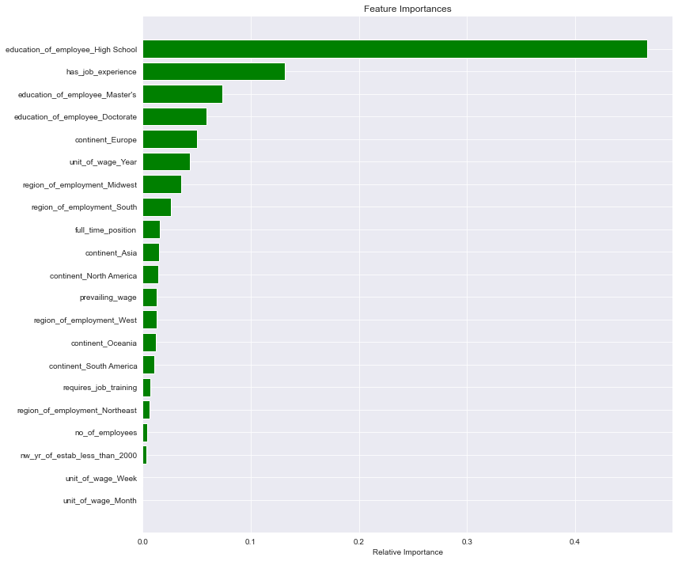

```python
feature_names = X_train.columns
importances = xgb_tuned.feature_importances_
indices = np.argsort(importances)

plt.figure(figsize=(12,12))
plt.title('Feature Importances')
plt.barh(range(len(indices)), importances[indices], color='green', align='center')
plt.yticks(range(len(indices)), [feature_names[i] for i in indices])
plt.xlabel('Relative Importance')
plt.show()
```

# Recommendations